# Bibliographic Essay

January 07 2018

## Historical

It is hard to believe that, prior to about 1920, there were many who considered Mendelian genetics to be incompatible with Darwinian Evolution. It was the seminal work of, among others, R. A. Fisher, J. B. S. Haldane and Sewall Wright that led to their reconciliation and what is now known as the “Modern Synthesis” of evolutionary biology. The late historian, biologist and iconolclast Will Provine wrote of the early days of that period of resolution; the book that resulted from his Master’s thesis (William B. Provine 2001) is well worth reading. Provine also wrote a seminal biography of Sewall Wright, one of the greatest geneticists of the twentieth century (William B Provine 1986).

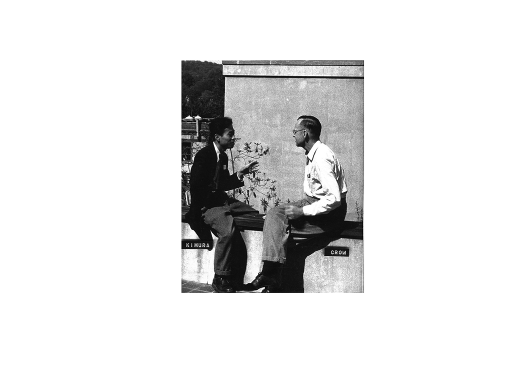

James Crow and his then student Motoo Kimura. Copyright Genetics Society of America

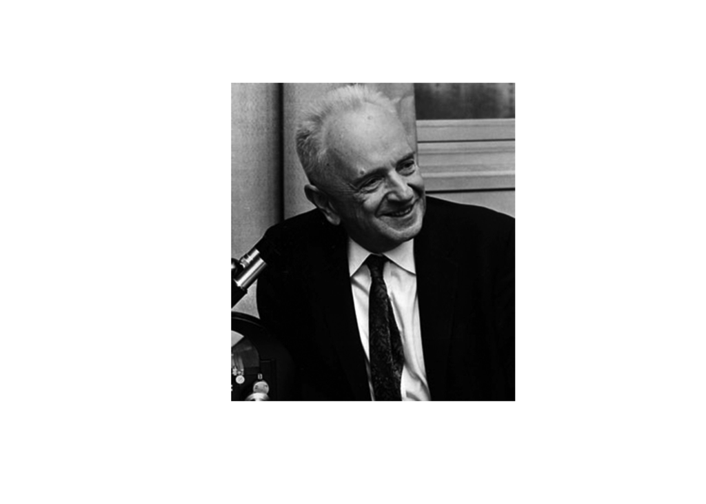

Theodosius Dobzhansky (1901-1975). Copyright Genetics Society of America

## Texts

There are basically two types of population genetics texts - the comprehensive and the overview. The classic in the former category is J. F. Crow and Kimura (1964); there are those who argue that anyone who wants to acquire a deep and basic understadning of the subject should start by digesting this in its entirety. It is, however, more than fifty years old, and much has happened since then. For more modern takes, see Hamilton (2009), Charlesworth and Charlesworth, or Hedrick (2004).

The shorter versions tend to be much more accessible, however that can be both a blessing and a curse, as often they overdo compression of difficult concepts. The classic in this genre is Mettler and Gregg; Three others worthy of note are J. G. Crow (1986), Gillespie (2006) and Hartl and Clark (2006). The most recent of these books, Nielsen and Slatkin (2013), is one that we will refer to regularly as we progress.

Finally, Joe Felsenstein has produced a comprehensive online treatment of theoretical population genetics (Felsenstein 2015). It is free of charge and can be downloaded as a pdf file. We will refer to this often - indeed it can be considered a companion volume, providing the theoretical background that we will frequently gloss over.

For a quick overview of the main themes of Felsenstein see http://evolution.gs.washington.edu/gecco.pdf

# References

Crow, J F, and M Kimura. 1964. *An Introduction to Population Genetics Theory*. Blackburn Press. https://books.google.com/books?id=VWqKPwAACAAJ.

Crow, J. G. 1986. *Basic Concepts in Population, Quantitative, and Evolutionary Genetics*. W H Freeman & Co (Sd).

Dobzhansky, Theodosius. 1970. *Genetics of the Evolutionary Process*. Columbia University Press.

Felsenstein, Joseph. 2015. “Theoretical Population Genetics.” Online. http://evolution.gs.washington.edu/pgbook/pgbook.pdf.

Gillespie, John. 2006. “Stochastic Processes in Evolution.” In *Evolutionary Genetics*, edited by Charles W Fox and Jason B Wolf, 65–79. Oxford Univeristy Press.

Hamilton, Matthew. 2009. *Population Genetics*. Wiley-Blackwell.

Hartl, Daniel L, and Andrew G Clark. 2006. *Principles of Population Genetics, Fourth Edition*. Sinauer Associates, Inc.

Hedrick, Philip W. 2004. *Genetics of populations*. Jones; Bartlett. doi:10.1017/CBO9781107415324.004.

Kimura, Motoo. 1985. *The neutral theory of molecular evolution*. Cambridge University Press.

———. 1995. *Population Genetics, Molecular Evolution, and the Neutral Theory: Selected Papers*. University Of Chicago Press.

Lewontin, R. C., John Moore, W. B. Provine, and Bruce Wallace. 1981. *Dobzhansky’s Genetics of Natural Populations I-Xliii*. Columbia Univ Pr.

Nielsen, R, and M Slatkin. 2013. *An Introduction to Population Genetics: Theory and Applications*. Macmillan Education. https://books.google.com/books?id=Iy08kgEACAAJ.

Provine, William B. 1986. *Sewall Wright and Evolutionary Biology (Science and Its Conceptual Foundations)*. Univ of Chicago Pr (Tx).

Provine, William B. 2001. *The origins of theoretical population genetics*. University of Chicago Press.